# Call of Duty Analysis Project

Darshan Sivarajah

01-03-2025

## Exploration

### Variable Analysis: Choice

Choice is a categorical variable. It tends to be a value that is either in Map1 or Map2 for that specific observation (except the times when the Map1 and Map2 values are missing), so it seems like players get to choose which option out of Map1 and Map2 they want to play on. There is also a MapVote variable showing the vote outcome, which backs my assumption.

The most common choices were Crossroads Strike, Diesel and Standoff, being selected in 54, 49 and 47 games respectively. The least common choice was Miami, being picked 3 times. A visualization of the number of times each map was chosen can be seen below. A table with a view of the times each map is chosen can be viewed in Appendix A.

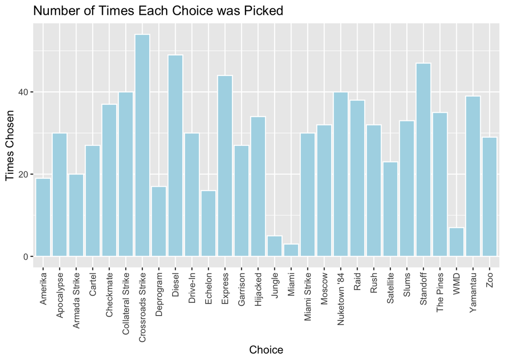

### Variable Analysis: Eliminations

Eliminations is a quantitative variable that represents the number of kills a players gets in a given game. Depending on the game mode this can also effect the overall score of the game.

If we were to ignore observations where there is an NA in the Eliminations column, we can observe the average Eliminations:

```
## # A tibble: 8 × 3
##   GameType            Avg_Elim count_games
##   <chr>                  <dbl>       <int>
## 1 Hardpoint               24.7         159
## 2 Domination              22.3           3
## 3 HC - Domination         18.1          11
## 4 TDM                     17.6         171
## 5 HC - Hardpoint          17.3          97
## 6 Kill Confirmed          15.7           6
## 7 HC - TDM                15.6         345
## 8 HC - Kill Confirmed     10.9          14
```

We can see that the average number of eliminations is highest in the game mode Hardpoint, with 24.7 eliminations per game. It also seems to be a relatively popular game-type, played 159 times. Domination is very high up in the order, however it has a very small sample size of 3 games, which implies that it isn’t popular.

Below are the quartile splits for eliminations, ignoring the 31 NAs.

```
##   min max firstQuartile    mean thirdQuartile median       sd
## 1   1  60            13 17.9727            22     17 7.996692
```

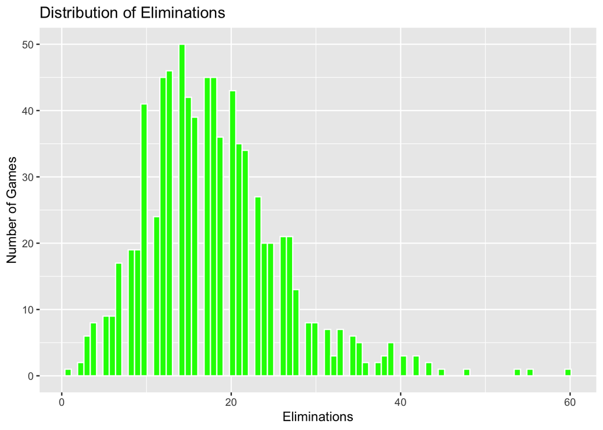

### Variable Analysis: TotalXP

TotalXP is a quantitative variable which determines how much progress a player makes in their ‘level’. Leveling up allows players to unlock new weapons, cosmetics, etc.

There are 31 observations where the TotalXP value is NA. After removing those instances, this is the summary:

```
##    min   max firstQuartile    mean thirdQuartile  median       sd
## 1 1935 45310       9878.25 15490.8       19921.5 14721.5 6972.383
```

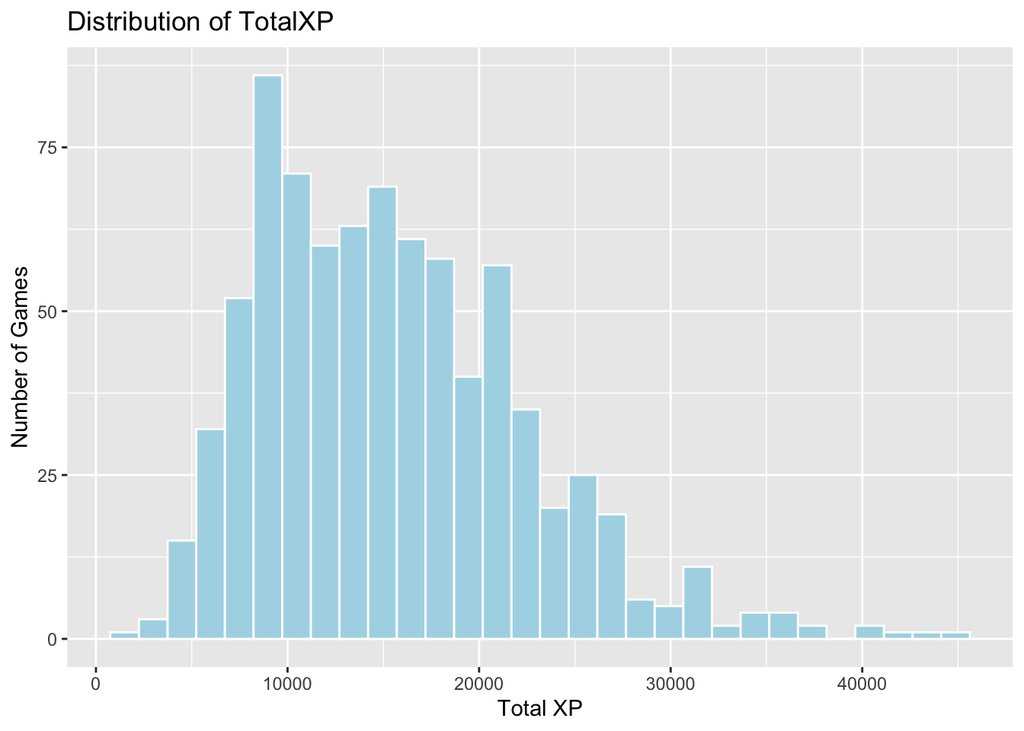

The plot shows a broad range of total XP earned, with more players at lower levels than very high levels. The graph for TotalXP observations looks to be a right-skewed. The average TotalXP in a game can be seen at 15490.8. The skewness indicates that while the average game may have moderate experience, there are a number of highly experienced groups that may pull the mean up.

## Answering Questions

### What is the breakdown of the players’ match outcomes (win, lose or draw)?

The first step would be to split the Result value into two columns - one with the player’s team score and the player’s opponent’s score. The next step would be to create indicator variables to signify the outcome for the player (Won, Draw and Lost). Using these separated values, we can calculate the proportions and create a pie chart. The code written to manipulate the data for this task can be viewed in Appendix 1.

The ratio of games won, drawn and lost by the player is 0.5459057, 0.007444169 and 0.4466501 respectively.

These proportions can be visualized in a pie chart.

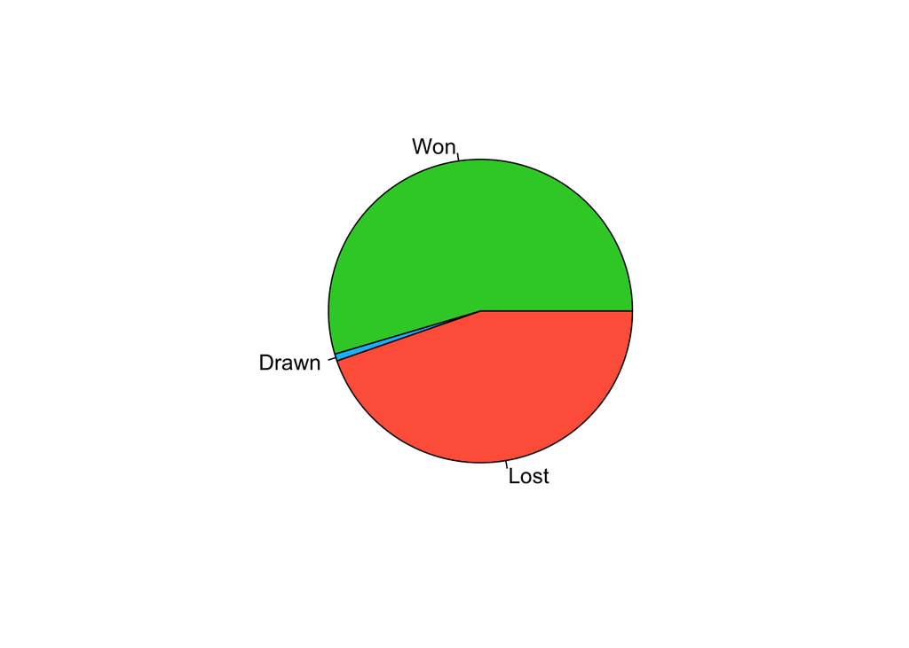

The player has won 54.6% of their games, and have lost 44.7% of their games. There are very few instances when they have drawn a game (0.7%).

### What is the relationship between the TotalXP in a game and the number of Eliminations in a game?

This can easily be understood by visualizing the relationship between TotalXP and Eliminations. The game-type may have an effect on the relationship since they may apply different rules and gaols to the game, so we can create separate plots for each game type to provide us another perspective.

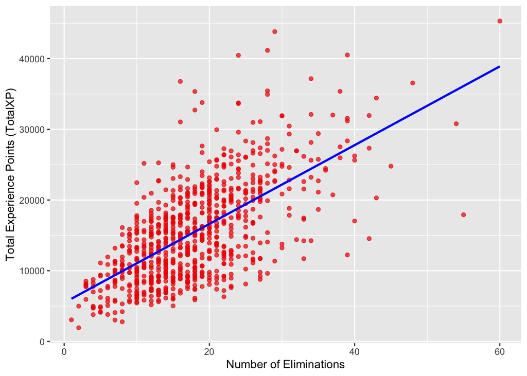

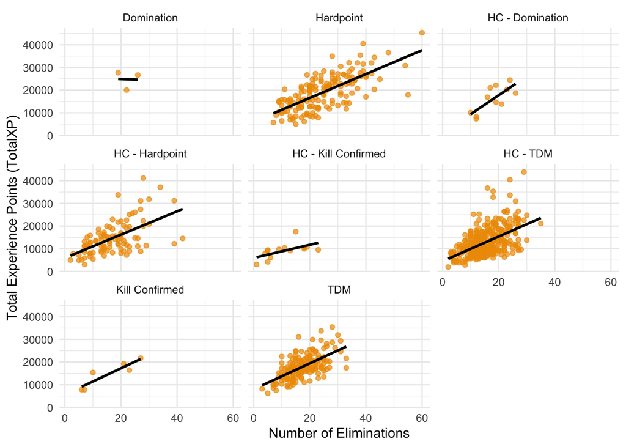

From the first plot, without taking game-type into consideration, we can see that there is a positive association between TotalXP and Number of Eliminations. The variance increases as the number of eliminations increases, which isn’t an issue as this is an inference question.

In conclusion, we can safely assume that the more eliminations a player makes, the higher their total XP would be.

### Which maps are the most likely to win the map vote when they are an option?

The first step in answering this question is to do data cleaning. We must remove rows where the player joined the lobby after the vote, as well as rows where the map was chosen as a result of a tie. To remove rows where the player joined after the vote, we can simply remove rows where the MapVote variable value is blank. To remove the rows where the vote is tied, we can separate MapVote into two columns (‘Vote1’ and ‘Vote2’) and check if they are the same. If the votes are the same, we filter out those rows.

After that, it is important that the names of the maps are correctly spelled, without leading or trailing spaces. We can look at the distinct values for the Map1, Map2 and Choice columns in the cod_data data and pick out the typos. To ensure that the spelling is correct, we can refer to the cod_maps data which contains the names of all the maps. We can then replace the incorrect entries.

Once the cleaning is done, we should be ready to put the data in a format to do calculations. To find the percentage we will need to two sets of figures: the number of times each map is voted to be played and the number of times each map is an option.

To get the number of times each map is played, we can simply group by Choice and use summarize() to count the instances. We then convert this to a data frame. To find the number of times each map appeared as an option, we can apply a similar approach that we took to get the times each map was chosen. We group by Map1, summarize to count the number of times it appears, then arrange. The same is done for Map2. We then combine the data frames together and create a new column where we add the counts for Map1 and Map2 together.

Finally, we can combine the two resulting data frames together, before dividing the times each map was chosen by the frequency of the map being an option, and multiplying it by 100. We can arrange this in decreasing order to see the highest percentage maps first.

The code for the data wrangling and manipulation can be viewed in Appendix 2.

There have been games played in 28 unique maps. Crossroads Strike is picked 41 times, followed by Diesel with 38 and Express with 34. There are 6 maps where 30 or more games have been played, and there aren’t many games separating them. Miami and WMD are the least popular with 2 games, followed by Jungle with 3 games each.

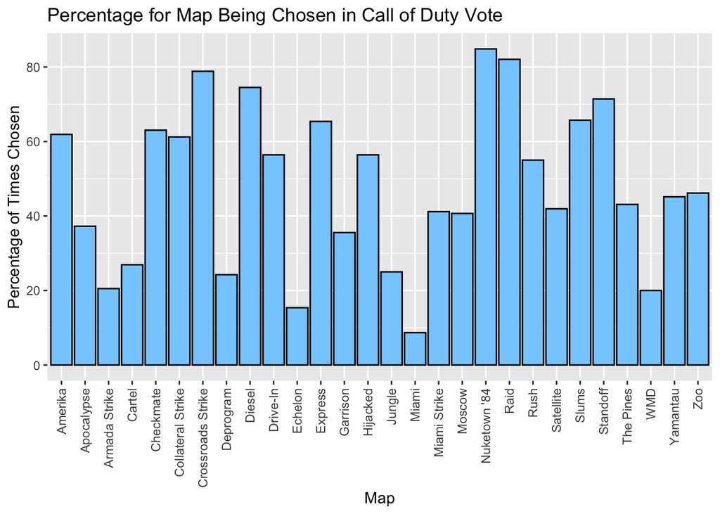

Nuketown ’84 was the most popular map, with an 84.85% rate of being picked when it appeared as an option. Crossroads Strike, Raid, Diesel and Standoff were make up the rest of the top five, getting picked more than 71% of the time. A table with all the values can be viewed in Appendix 2.

### Create a model using three different approaches, that predicts if a player wins a game based on the other variables in the data set. Choose a model that you think is best.

For the data wrangling portion, I created variables indicating if the player won (Win) or lost (Loss) the game (a ‘0’ in both fields implies a tie. I also narrowed down the variables in the data set to get rid of seemingly redundant variables (based on my understanding of their meanings and through intuition). For instance, I don’t think MapVote plays a legitimate part in predicting a win or loss, so I removed that. Date was a variable that I wanted to include, however it caused issues when testing the Linear Discriminant Analysis model, so I removed it. I also removed observations with NA values.

I performed a 80/20 training/validation split so that I could calculate the accuracy of the models at the end, to be able to compare their predictive qualities.

The three classification approaches that I chose were Random Forest, Linear Discriminant Analysis and Logistic Regression.

Random Forest is a machine learning approach that repeatedly selects bootstrap samples. A tree is then fit to each samples. The various predictions produced from these various models are combined in this classification task by majority vote. Bootstrapping is when a sample is taken of a data set using replacement, obtaining a sample with as many observations as the data set itself. As a result, some observations may not be used. A limitation of this is that the trees are usually highly correlated, resulting in highly correlated predictions.

Linear Discrimination Analysis is a dimensionality reduction technique that works by projecting data from multiple dimensions onto one dimension so it can be classified more easily. It identifies a linear combination of features that can classify the response. Linear Discrimination Analysis makes several assumptions about the data: that sample measurements are independent, distributions are normal, and co-variance is equal across classes. Any violations of these assumptions means a significant decrease in accuracy.

Last but not least, Logistic Regression. This machine learning technique models probability; in our case, of a binary outcome. With the resulting probabilities, we can compare it to a set threshold to see the ‘success’ and ‘failures’. I chose Win = 1 as the success, and Win = 0 as the failure. I decided on using 0.5 as a threshold, with which we can compare the predicted probabilities to.

Based on the accuracy scores for the three models, the model produced from the Linear Discriminant Analysis approach is best, with an accuracy rate of 0.5802469 It narrowly beats the Logistic Regression model, which has an accuracy of 0.5740741. The Random Forest approach scored 0.5246914. The calculations can be viewed in Appendix 3.

Since the Linear Discriminant Analysis approach is best, I would suggest using that model. This is created using:

```r
bestModel <- lda(Win ~ ., data = Train)
```

A output with more details can be found in Appendix 3.

## Appendices

### Looking at Missing Data

```
##           Map1           Map2         Choice        MapVote           Date
##              0              0              0              0              0
##    FullPartial         Result   Eliminations         Deaths          Score
##              0              0             31             31             31
##         Damage        TotalXP  PrimaryWeapon         XPType  DidPlayerVote
##             31             31              0              0              0
##       GameType       Confirms         Denies     Objectives ObjectiveKills
##              0            817            817            799            567
##       Captures       Diffuses         Plants      Detonates       Deposits
##            819            837            837            837            837
##       Time_Sec       Time_Min
##            585            585
```

Having a view of number of NAs per variable gives us an idea of how many observations we may have to ‘clean’ later when we have to manipulate the data to answer questions.

### Appendix A

The different values are:

```
##  [1] "Miami Strike"      "Moscow"            "Yamantau"
##  [4] "Drive-In"          "Collateral Strike" "Raid"
##  [7] "WMD"               "Standoff"          "Crossroads Strike"
## [10] "Deprogram"         "Nuketown '84"      "Jungle"
## [13] "Rush"              "Zoo"               "Slums"
## [16] "Echelon"           "Garrison"          "Cartel"
## [19] "Express"           "The Pines"         "Apocalypse"
## [22] "Diesel"            "Amerika"           "Checkmate"
## [25] "Hijacked"          "Satellite"         "Miami"
## [28] "Armada Strike"
```

```r
sprintf("There are %s unqiue values.", length(unique(cod_data$Choice)))
```

```
## [1] "There are 28 unqiue values."
```

```r
sprintf("The are %s row(s) where the value for 'Choice' is NA.", sum(is.na(cod_data$Choice)))
```

```
## [1] "The are 0 row(s) where the value for 'Choice' is NA."
```

Manually changing the misspelled words and checking if all have been fixed:

```r
cod_data <- cod_data %>%
  filter(Choice != "")

cod_data$Choice[cod_data$Choice == "APocalypse"] <- "Apocalypse"
cod_data$Choice[cod_data$Choice == "Drive-in"] <- "Drive-In"
cod_data$Choice[cod_data$Choice == "Collaterel Strike"] <- "Collateral Strike"
cod_data$Choice[cod_data$Choice == "Deisel"] <- "Diesel"
cod_data$Choice[cod_data$Choice == "Nuketown '84 Halloween"] <- "Nuketown '84"
cod_data$Choice[cod_data$Choice == "Collateral"] <- "Collateral Strike"
cod_data$Choice[cod_data$Choice == "Apocolypse"] <- "Apocalypse"
cod_data$Choice[cod_data$Choice == "Riad"] <- "Raid"

sprintf("There are %s unqiue values.", length(unique(cod_data$Choice))) #to check if there are only 28 unique observations left
```

```
## [1] "There are 28 unqiue values."
```

```
## # A tibble: 28 × 2
##    Choice            Count
##    <chr>             <int>
##  1 Crossroads Strike    54
##  2 Diesel               49
##  3 Standoff             47
##  4 Express              44
##  5 Collateral Strike    40
##  6 Nuketown '84         40
##  7 Yamantau             39
##  8 Raid                 38
##  9 Checkmate            37
## 10 The Pines            35
## # ℹ 18 more rows
```

### Appendix 1

Splitting Result value into two columns:

```r
cod_data_split <- cod_data %>%
  filter(Result != '') %>%
  separate_wider_delim(cols = Result, delim = "-", names = c("PlayersTeam", "PlayersOpponents"))
```

Creating indicator variables and calculating the proportions for games won, drawn and lost.

```r
cod_data_outcomes <- cod_data_split %>%
  mutate(across(PlayersTeam, as.numeric)) %>%
  mutate(across(PlayersOpponents, as.numeric)) %>%
  mutate(Won = ifelse(PlayersTeam > PlayersOpponents, 1, 0),
         Draw = ifelse(PlayersTeam == PlayersOpponents, 1, 0),
         Lost = ifelse(PlayersTeam < PlayersOpponents, 1, 0))

propWon <- sum(cod_data_outcomes$Won) /  nrow(cod_data_outcomes)
propDraw <- sum(cod_data_outcomes$Draw) /  nrow(cod_data_outcomes)
propLost <- sum(cod_data_outcomes$Lost) /  nrow(cod_data_outcomes)

propWon
```

```
## [1] 0.5459057
```

```r
propDraw
```

```
## [1] 0.007444169
```

```r
propLost
```

```
## [1] 0.4466501
```

### Appendix 2

```r
cod_data_map_vote <- cod_data[cod_data$MapVote != "", ] #filters out games where player joined lobby after the vote

cod_data_map_vote %>%
  filter(!grepl(" to ", MapVote)) #shows rows that don't fit the format 'Vote1 to Vote2 [not visible because changed in main code]
```

```
##  [1] Map1           Map2           Choice         MapVote        Date
##  [6] FullPartial    Result         Eliminations   Deaths         Score
## [11] Damage         TotalXP        PrimaryWeapon  XPType         DidPlayerVote
## [16] GameType       Confirms       Denies         Objectives     ObjectiveKills
## [21] Captures       Diffuses       Plants         Detonates      Deposits
## [26] Time_Sec       Time_Min
## <0 rows> (or 0-length row.names)
```

Creating a uniform format:

```r
cod_data$MapVote[cod_data$MapVote == "4 o 0"] <- "4 to 0"
cod_data$MapVote[cod_data$MapVote == "2 o 0"] <- "2 to 0"

cod_data_map_vote <- cod_data[cod_data$MapVote != "", ] #repeat assignment to update after cleaning original data set
```

Creating two separate columns for each Vote count and recognizing ties:

```r
cod_data_map_vote <- cod_data_map_vote %>%
  separate_wider_delim(cols = MapVote, delim = " to ", names = c("Vote1", "Vote2")) %>%
  mutate(Tie = ifelse(Vote1 == Vote2, 1, 0)) #creates variable that indicates a tie (1) or not (0)

cod_data_map_vote <- cod_data_map_vote[cod_data_map_vote$Tie != 1, ] #removes rows with tied vote

unique(cod_data_map_vote$Choice)
```

```
##  [1] "Miami Strike"      "Moscow"            "Drive-In"
##  [4] "Raid"              "Standoff"          "Deprogram"
##  [7] "Jungle"            "Crossroads Strike" "Express"
## [10] "The Pines"         "Yamantau"          "Rush"
## [13] "Apocalypse"        "Collateral Strike" "Slums"
## [16] "Diesel"            "Amerika"           "Nuketown '84"
## [19] "Zoo"               "Checkmate"         "WMD"
## [22] "Hijacked"          "Echelon"           "Garrison"
## [25] "Cartel"            "Satellite"         "Miami"
## [28] "Armada Strike"
```

```r
cod_data_map_vote %>%
  group_by(Choice) %>%
  summarize(Count = n()) %>%
  arrange(desc(Count))
```

```
## # A tibble: 28 × 2
##    Choice            Count
##    <chr>             <int>
##  1 Crossroads Strike    41
##  2 Diesel               38
##  3 Express              34
##  4 Raid                 32
##  5 Collateral Strike    30
##  6 Standoff             30
##  7 Checkmate            29
##  8 Nuketown '84         28
##  9 Yamantau             28
## 10 The Pines            25
## # ℹ 18 more rows
```

```r
cod_data_map_vote
```

```
## # A tibble: 571 × 29
##    Map1    Map2  Choice Vote1 Vote2 Date  FullPartial Result Eliminations Deaths
##    <chr>   <chr> <chr>  <chr> <chr> <chr> <chr>       <chr>         <int>  <int>
##  1 Moscow  Miam… Miami… 5     0     6/6/… Full        100-97           22     17
##  2 Moscow  WMD   Moscow 2     0     6/6/… Full        76-89            20     15
##  3 Drive-… Jung… Drive… 2     0     6/6/… Full        80-100           10     19
##  4 Crossr… Raid  Raid   4     3     6/6/… Full        85-100            7     18
##  5 The Pi… Stan… Stand… 5     1     6/6/… Full        100-70           18     14
##  6 Echelon Depr… Depro… 1     0     6/12… Full        46-65            11     23
##  7 Jungle  Hija… Jungle 1     0     6/13… Full        100-94           10     11
##  8 WMD     Stan… Stand… 3     1     6/13… Full        100-77           17     12
##  9 Diesel  Raid  Raid   4     2     6/13… Full        100-98           14     12
## 10 Slums   Cros… Cross… 1     0     6/18… Full        250-54           10     15
## # ℹ 561 more rows
## # ℹ 19 more variables: Score <int>, Damage <int>, TotalXP <int>,
## #   PrimaryWeapon <chr>, XPType <chr>, DidPlayerVote <chr>, GameType <chr>,
## #   Confirms <int>, Denies <int>, Objectives <int>, ObjectiveKills <int>,
## #   Captures <int>, Diffuses <lgl>, Plants <lgl>, Detonates <lgl>,
## #   Deposits <lgl>, Time_Sec <int>, Time_Min <int>, Tie <dbl>
```

Comparing the number of values with the values listed in the cod_maps data set, it is clear to see that a number of them are typos. Data cleaning is required to fix this.

NOTE: Miami and Miami Strike are listed as two different maps, so I will keep them separate. Miami Strike replaced Miami. Collateral Strike is a map while Collateral is not, so all instances of Collateral will become Collateral Strike.

Manually changing the misspelled Choice names:

```r
#data cleaning:

cod_data_map_vote$Choice[cod_data_map_vote$Choice == "APocalypse"] <- "Apocalypse"
cod_data_map_vote$Choice[cod_data_map_vote$Choice == "Drive-in"] <- "Drive-In"
cod_data_map_vote$Choice[cod_data_map_vote$Choice == "Collaterel Strike"] <- "Collateral Strike"
cod_data_map_vote$Choice[cod_data_map_vote$Choice == "Deisel"] <- "Diesel"
cod_data_map_vote$Choice[cod_data_map_vote$Choice == "Nuketown '84 Halloween"] <- "Nuketown '84"
cod_data_map_vote$Choice[cod_data_map_vote$Choice == "Collateral"] <- "Collateral Strike"
cod_data_map_vote$Choice[cod_data_map_vote$Choice == "Apocolypse"] <- "Apocalypse"
```

Now, we repeat this provess for the Map1 and Map2 columns:

```r
unique(cod_data_map_vote$Map1)
```

```
##  [1] "Moscow"            "Drive-In"          "Crossroads Strike"
##  [4] "The Pines"         "Echelon"           "Jungle"
##  [7] "WMD"               "Diesel"            "Slums"
## [10] "Express"           "Cartel"            "Deprogram"
## [13] "Rush"              "Apocalypse"        "Miami Strike"
## [16] "Collateral Strike" "Raid"              "Nuketown '84"
## [19] "Garrison"          "Amerika"           "Standoff"
## [22] "Yamantau"          "Checkmate"         "Zoo"
## [25] "Hijacked"          "Jungle "           "Ruah"
## [28] "Satellite"         "Miami"             "Collateral"
## [31] "Riad"              "Miami "            "Armada Strike"
## [34] "Collateral Striek" "Miami Stirke"      "Collaterol Strike"
## [37] "Drive-in"          "Deprogam"          "Rush "
## [40] "Zoo "
```

There are 40 unique values We know there are 28 observations for the cod_maps data set, so there are 12 typos to fix.

```
##  [1] "Moscow"            "Drive-In"          "Crossroads Strike"
##  [4] "The Pines"         "Echelon"           "Jungle"
##  [7] "WMD"               "Diesel"            "Slums"
## [10] "Express"           "Cartel"            "Deprogram"
## [13] "Rush"              "Apocalypse"        "Miami Strike"
## [16] "Collateral Strike" "Raid"              "Nuketown '84"
## [19] "Garrison"          "Amerika"           "Standoff"
## [22] "Yamantau"          "Checkmate"         "Zoo"
## [25] "Hijacked"          "Satellite"         "Miami"
## [28] "Armada Strike"
```

```r
unique(cod_data_map_vote$Map2)
```

```
##  [1] "Miami Strike"           "WMD"                    "Jungle"
##  [4] "Raid"                   "Standoff"               "Deprogram"
##  [7] "Hijacked"               "Crossroads Strike"      "Slums"
## [10] "Moscow"                 "Yamantau"               "Express"
## [13] "Collateral Strike"      "Drive-In"               "Diesel"
## [16] "Amerika"                "Echelon"                "Apocalypse"
## [19] "Zoo"                    "Nuketown '84"           "Rush"
## [22] "Cartel"                 "The Pines"              "Garrison"
## [25] "Checkmate"              "Miami Stirke"           "Armada Strike"
## [28] "Miami"                  "Satellite"              "Collateral"
## [31] "yamantau"               "Drive-in"               "Nuketown '84 Halloween"
## [34] "Miami Sstrike"          "Amrada Strike"
```

```r
#data cleaning:

cod_data_map_vote$Map2[cod_data_map_vote$Map2 == "Miami Sstrike"] <- "Miami Strike"
cod_data_map_vote$Map2[cod_data_map_vote$Map2 == "Miami Stirke"] <- "Miami Strike"
cod_data_map_vote$Map2[cod_data_map_vote$Map2 == "yamantau"] <- "Yamantau"
cod_data_map_vote$Map2[cod_data_map_vote$Map2 == "Amrada Strike"] <- "Armada Strike"
cod_data_map_vote$Map2[cod_data_map_vote$Map2 == "Drive-in"] <- "Drive-In"
cod_data_map_vote$Map2[cod_data_map_vote$Map2 == "Nuketown '84 Halloween"] <- "Nuketown '84"
cod_data_map_vote$Map2[cod_data_map_vote$Map2 == "Collateral"] <- "Collateral Strike"

unique(cod_data_map_vote$Map2)
```

```
##  [1] "Miami Strike"      "WMD"               "Jungle"
##  [4] "Raid"              "Standoff"          "Deprogram"
##  [7] "Hijacked"          "Crossroads Strike" "Slums"
## [10] "Moscow"            "Yamantau"          "Express"
## [13] "Collateral Strike" "Drive-In"          "Diesel"
## [16] "Amerika"           "Echelon"           "Apocalypse"
## [19] "Zoo"               "Nuketown '84"      "Rush"
## [22] "Cartel"            "The Pines"         "Garrison"
## [25] "Checkmate"         "Armada Strike"     "Miami"
## [28] "Satellite"
```

A table that gives us a thorough understanding of the individual percentages for each map:

```r
choice_counts_summary <- choice_counts_summary %>%
  arrange(Choice) #takes count of number times each map was chosen from the voting and arranges with most picked map at the top

choice_counts_summary = data.frame(unclass(choice_counts_summary), check.names = FALSE)

map1_counts <- cod_data_map_vote %>%
  group_by(Map1) %>%
  summarize(Count = n()) %>%
  arrange(Map1) %>%
  rename(Count1 = Count)

map2_counts <- cod_data_map_vote %>%
  group_by(Map2) %>%
  summarize(Count = n()) %>%
  arrange(Map2) %>%
  rename(Count2 = Count)

total_map_counts <- cbind(map1_counts, map2_counts) %>% #combines map1_counts and map2_counts so that we can combine the totals
  mutate(Num_Options = Count1 + Count2) %>% #calculates number of times map showed up in the voting overall
  dplyr::select(Map1, Num_Options) %>%
  rename(Map = Map1)

percentage_map_chosen <- cbind(total_map_counts, choice_counts_summary) %>%
  mutate(Percentage_Chosen = Count / Num_Options * 100) %>% #calculates the percentage; (times picked) / (times it was an option) * 100
  dplyr::select(Map, Percentage_Chosen, Count, Num_Options) %>%
  arrange(desc(Percentage_Chosen))

percentage_map_chosen
```

```
##                  Map Percentage_Chosen Count Num_Options
## 1       Nuketown '84         84.848485    28          33
## 2               Raid         82.051282    32          39
## 3  Crossroads Strike         78.846154    41          52
## 4             Diesel         74.509804    38          51
## 5           Standoff         71.428571    30          42
## 6              Slums         65.714286    23          35
## 7            Express         65.384615    34          52
## 8          Checkmate         63.043478    29          46
## 9            Amerika         61.904762    13          21
## 10 Collateral Strike         61.224490    30          49
## 11          Drive-In         56.410256    22          39
## 12          Hijacked         56.410256    22          39
## 13              Rush         55.000000    22          40
## 14               Zoo         46.153846    18          39
## 15          Yamantau         45.161290    28          62
## 16         The Pines         43.103448    25          58
## 17         Satellite         41.935484    13          31
## 18      Miami Strike         41.176471    21          51
## 19            Moscow         40.677966    24          59
## 20        Apocalypse         37.254902    19          51
## 21          Garrison         35.555556    16          45
## 22            Cartel         26.923077    14          52
## 23            Jungle         25.000000     3          12
## 24         Deprogram         24.242424     8          33
## 25     Armada Strike         20.512821     8          39
## 26               WMD         20.000000     2          10
## 27           Echelon         15.384615     6          39
## 28             Miami          8.695652     2          23
```

### Appendix 3

Building the models and finding the accuracy scores:

```r
#building the models:
#Random Forest
set.seed(123)
rfModel <- randomForest(as.factor(Win) ~ ., data = Train, ntree = 500, mtry = 3)

#Linear Discriminant Analysis
ldaModel <- lda(Win ~ ., data = Train)

#Logistic Regression
lrModel <- glm(Win ~ ., family = "binomial", data = Train)
set.seed(NULL)

#testing accuracy:
#Random Forest accuracy:
set.seed(123)
rfPredWin <- predict(rfModel, newdata = Validation, type = "response")
mean(rfPredWin == Validation$Win)
```

```
## [1] 0.5246914
```

```r
set.seed(NULL)

#Linear Discriminant Analysis accuracy:
ldaPredWin <- predict(ldaModel, newdata = Validation, type = "response")
mean(ldaPredWin$class == Validation$Win)
```

```
## [1] 0.5802469
```

```r
#Logistic Regression accuracy:
lrPredWin <- predict(lrModel, newdata = Validation, type = "response")
lrPredWin <- ifelse(lrPredWin > 0.5, 1, 0)
mean(lrPredWin == Validation$Win)
```

```
## [1] 0.5740741
```

Chosen model:

```r
ldaModel
```

```
## Call:
## lda(Win ~ ., data = Train)
##
## Prior probabilities of groups:
##         0         1
## 0.5326087 0.4673913
##
## Group means:
##   FullPartialPartial Eliminations   Deaths    Score   Damage  TotalXP
## 0          0.0787172     19.02332 16.37318 3181.385 1474.262 15912.08
## 1          0.1162791     17.00000 17.55482 2795.698 1486.598 14878.15
##   PrimaryWeaponAUG PrimaryWeaponAUG  PrimaryWeaponDMR 14 PrimaryWeaponFARA-83
## 0       0.05539359       0.000000000          0.04373178           0.03498542
## 1       0.04983389       0.009966777          0.03986711           0.06312292
##   PrimaryWeaponFFAR 1 PrimaryWeaponGroza PrimaryWeaponKrig 6
## 0         0.005830904          0.1282799          0.02332362
## 1         0.000000000          0.1029900          0.02657807
##   PrimaryWeaponKSP 45 PrimaryWeaponLC-10 PrimaryWeaponM16 PrimaryWeaponM60
## 0          0.01166181         0.02332362       0.12536443       0.04664723
## 1          0.02657807         0.02990033       0.09966777       0.07973422
##   PrimaryWeaponMagnum PrimaryWeaponMG 82 PrimaryWeaponMilano
## 0         0.002915452          0.1516035          0.02623907
## 1         0.006644518          0.1262458          0.02325581
##   PrimaryWeaponMilano 821 PrimaryWeaponMP5 PrimaryWeaponPelington 703
## 0              0.01166181       0.04956268                 0.05247813
## 1              0.01328904       0.06644518                 0.05980066
##   PrimaryWeaponPellington PrimaryWeaponQBZ-83 PrimaryWeaponRPD
## 0              0.02915452          0.05247813       0.05830904
## 1              0.05980066          0.03322259       0.04651163
##   PrimaryWeaponShadowHunter PrimaryWeaponType 63 PrimaryWeaponXM4
## 0               0.000000000           0.01749271      0.005830904
## 1               0.003322259           0.01328904      0.000000000
##   XPTypeDouble XP + 10% XPTypeDouble XP + 10%  GameTypeHardpoint
## 0             0.6268222            0.002915452         0.1895044
## 1             0.6378738            0.000000000         0.2026578
##   GameTypeHC - Domination GameTypeHC - Hardpoint GameTypeHC - Kill Confirmed
## 0             0.023323615             0.09912536                  0.01749271
## 1             0.009966777             0.14617940                  0.01661130
##   GameTypeHC - TDM GameTypeKill Confirmed GameTypeTDM
## 0        0.4693878            0.011661808   0.1865889
```

[output cut: 27 more lines]

```
## PrimaryWeaponPellington      2.008963e+00
## PrimaryWeaponQBZ-83          4.186813e-01
## PrimaryWeaponRPD             6.725375e-01
## PrimaryWeaponShadowHunter    3.096805e+00
## PrimaryWeaponType 63         1.084554e+00
## PrimaryWeaponXM4            -1.548834e+00
## XPTypeDouble XP + 10%        2.940918e-01
## XPTypeDouble XP + 10%       -1.957153e+00
## GameTypeHardpoint            1.375220e+00
## GameTypeHC - Domination      7.186021e-01
## GameTypeHC - Hardpoint       3.043011e+00
## GameTypeHC - Kill Confirmed  1.845273e+00
## GameTypeHC - TDM             2.159289e+00
## GameTypeKill Confirmed      -1.377705e+00
## GameTypeTDM                  1.466641e+00
```